# Step 2: PacBio HiFi Quality Filtering

# 1 Introduction

## 1.1 Purpose

This notebook is **Step 2** of the PacBio HiFi full-length 16S rRNA workflow. It reads the validated original FASTQ paths mapped by [Step 1](https://github.com/changlabs/DADA2_16S_PacBio_HiFi_Workflow/blob/main/R/notebooks/1_data_integrity_and_sample_mapping.md), implements PacBio-style read statistics and Q20 filtering in R, and creates an auditable QC report before [Step 3 (Primer Trimming with Cutadapt)](https://github.com/changlabs/DADA2_16S_PacBio_HiFi_Workflow/blob/main/R/notebooks/3_primer_trimming.md). After primer trimming, [Step 4](https://github.com/changlabs/DADA2_16S_PacBio_HiFi_Workflow/blob/main/R/notebooks/4_dada2_parameter_selection.md) supports `maxEE` selection and [Step 5](https://github.com/changlabs/DADA2_16S_PacBio_HiFi_Workflow/blob/main/R/notebooks/5_dada2_pipeline.md) performs the complete DADA2 analysis.

PacBio HiFi reads already span the full amplified 16S region. This notebook therefore assesses complete-read length, GC content, and quality value (QV) and does not choose a positional truncation length. Reads below the configurable Q20 threshold are excluded from the filtered FASTQs used by subsequent steps.

## 1.2 Prerequisites

Before running this notebook:

- Complete [Step 1](https://github.com/changlabs/DADA2_16S_PacBio_HiFi_Workflow/blob/main/R/notebooks/1_data_integrity_and_sample_mapping.md) successfully.
- Keep the original FASTQs at the project-relative paths recorded in the Step 1 manifest.
- Confirm that data_integrity_and_sample_mapping.xlsx contains the `Sample_Manifest` worksheet.
- Install the R dependencies used by the workflow.

## 1.3 What This Notebook Does

1. **Reads the Step 1 manifest** and reconstructs portable paths to the validated FASTQ files.
2. **Streams every FASTQ** in fixed-size chunks.
3. **Calculates read statistics**, including read length, GC percentage, and quality value (QV) derived from mean base-error probability.
4. **Applies a quality threshold of Q20**, writing passing records to gzip-compressed filtered FASTQ files
5. **Streams the complete per-read audit table to a compressed TSV file** and accumulates compact histogram frequencies from every read.
6. **Creates pre-filter read-length and QV distributions** as inline figures and standalone PDFs.
7. **Exports a documented Excel workbook** with run settings, pre/post-filter sample QC, and a Column Dictionary.

## 1.4 Expected Input

- results/1_data_integrity_and_sample_mapping/data_integrity_and_sample_mapping.xlsx
- Original FASTQs referenced by `SourceFASTQPath` in the Step 1 manifest.

## 1.5 Expected Output

- results/2_quality_filtered_reads/quality_and_read_length_summary.xlsx
- results/2_quality_filtered_reads/per_read_statistics.tsv.gz
- results/2_quality_filtered_reads/Q20_filtered_fastq/
- results/2_quality_filtered_reads/read_length_distribution.pdf
- results/2_quality_filtered_reads/read_quality_distribution.pdf

# 2 Environment Setup

## 2.1 Load Required Packages

Load the packages used for streaming FASTQ files, building plots and tables, reading the [Step 1](https://github.com/changlabs/DADA2_16S_PacBio_HiFi_Workflow/blob/main/R/notebooks/1_data_integrity_and_sample_mapping.md) manifest, and writing documented Excel results. The shared helper functions are sourced from R/functions/.

```r
# Declare dependencies in one place so the notebook fails before reading or
# writing files when the environment is incomplete.
required_packages <- c(
  "data.table", "DT", "fs", "ggplot2", "here", "knitr",
  "openxlsx", "readxl", "ShortRead"
)

missing_packages <- required_packages[
  !vapply(required_packages, requireNamespace, quietly = TRUE, FUN.VALUE = logical(1))
]

if (length(missing_packages) > 0L) {
  stop(
    "Missing required package(s): ", paste(missing_packages, collapse = ", "),
    ". Install them before running Notebook 2."
  )
}

# Attach packages used repeatedly; less frequent calls remain namespace-qualified.
library(data.table)
library(fs)
library(ggplot2)
library(here)

# Reuse the same workbook and portable-link behavior as Notebook 1.
source(here("R", "functions", "add_sheet_to_excel_function.R"))
source(here("R", "functions", "build_column_dictionary_function.R"))
source(here("R", "functions", "render_output_links_function.R"))
source(here("R", "functions", "render_output_tree_function.R"))
source(here("R", "functions", "workflow_paths_function.R"))
```

# 3 Configuration

## 3.1 Define Input and Output Paths

Define all paths relative to the project root. The [Step 1](https://github.com/changlabs/DADA2_16S_PacBio_HiFi_Workflow/blob/main/R/notebooks/1_data_integrity_and_sample_mapping.md) workbook supplies sample identities, while the full project-relative source paths are resolved inside the current project so copied projects remain portable.

```r
# Step 1 inputs used by this notebook.
step1_folder <- workflow_results_dir("1_data_integrity_and_sample_mapping")
step1_workbook <- here(step1_folder, "data_integrity_and_sample_mapping.xlsx")
project_root <- here::here()

# Step 2 owns this complete output subtree.
results_folder <- workflow_results_dir("2_quality_filtered_reads")
filtered_fastq_folder <- here(results_folder, "Q20_filtered_fastq")
# Persist every read in a compressed TSV without Excel row limits or a full-table
# import into memory. Excel contains only the compact summary tables.
read_statistics_path <- here(results_folder, "per_read_statistics.tsv.gz")
workbook_path <- here(results_folder, "quality_and_read_length_summary.xlsx")
length_plot_path <- here(results_folder, "read_length_distribution.pdf")
quality_plot_path <- here(results_folder, "read_quality_distribution.pdf")
```

## 3.2 Define QC Parameters

```r
# Full-length bacterial 16S amplicons are commonly near 1.5 kb. These broad
# review bounds can be adjusted for another primer pair or target region.
expected_length_min <- 1200L
expected_length_max <- 1800L

# Match the user-adjustable QV filter in PacBio's HiFi-16S workflow. QV is
# calculated from the mean base-error probability, as documented by SeqKit.
read_qv_cutoff <- 20

# Count every read in bounded FASTQ chunks; retain frequencies, not read vectors.
stream_yield_size <- 10000L
samples_per_plot_page <- 6L
length_histogram_bin_width <- 20L
qv_histogram_bin_width <- 0.5
annotation_length_min <- 1800L
annotation_length_max <- 2000L

# Phred+33 is the standard FASTQ quality encoding used for these files.
quality_ascii_offset <- 33L
```

## 3.3 Validate Configuration

Validate inputs and parameter relationships before creating or replacing any Step 2 output.

```r
# Fail early when Step 1 artifacts are missing.
if (!file_exists(step1_workbook)) {
  stop("Step 1 workbook does not exist: ", step1_workbook)
}

# Prevent invalid thresholds or non-positive streaming limits.
if (expected_length_min < 1L || expected_length_max <= expected_length_min) {
  stop("Expected read-length bounds must satisfy 1 <= minimum < maximum.")
}
if (stream_yield_size < 1L || samples_per_plot_page != 6L ||
    length_histogram_bin_width <= 0 || qv_histogram_bin_width <= 0 ||
    annotation_length_max < annotation_length_min) {
  stop("Invalid streaming, histogram, annotation, or six-facet page configuration.")
}

# Create only this notebook's managed output folders.
dir_create(results_folder, recurse = TRUE)
dir_create(filtered_fastq_folder, recurse = TRUE)
```

The resolved inputs, managed result folder, quality threshold, and streaming settings are printed below so this report records the exact run configuration.

```
## Step 1 workbook: /Users/jon/Documents/workflows/DADA2_16S_PacBio_HiFi_Workflow/example/run_results/mapping_only/1_data_integrity_and_sample_mapping/data_integrity_and_sample_mapping.xlsx
```

```
## Original FASTQ paths resolved relative to: /Users/jon/Documents/workflows/DADA2_16S_PacBio_HiFi_Workflow
```

```
## Step 2 results folder: /Users/jon/Documents/workflows/DADA2_16S_PacBio_HiFi_Workflow/example/run_results/mapping_only/2_quality_filtered_reads
```

```
## Expected read-length range: 1200 to 1800 bp
```

```
## Per-read QV filtering cutoff: Q20
```

# 4 Functions

## 4.1 Define Table and FASTQ Helpers

Define the shared presentation behavior and a streaming FASTQ summarizer. Comments describe the memory bounds, quality conversion, and all-read frequency aggregation and paginated plotting.

```r
render_table <- function(x, caption = NULL, column_widths = NULL) {
  # Use one normalized data.frame for both HTML and GitHub renderers.
  table_data <- as.data.frame(x)

  if (knitr::is_html_output()) {
    # Force every column left and optionally widen selected columns. DataTables
    # uses zero-based targets, so subtract one from R column positions.
    column_definitions <- list(list(className = "dt-left", targets = "_all"))
    if (!is.null(column_widths)) {
      width_columns <- which(!is.na(column_widths) & nzchar(column_widths))
      column_definitions <- c(
        column_definitions,
        lapply(width_columns, function(column_index) {
          list(targets = column_index - 1L, width = column_widths[[column_index]])
        })
      )
    }

    # These are inspection tables: retain scrolling but remove sorting, search,
    # pagination, and entry-count controls.
    DT::datatable(
      table_data,
      caption = caption,
      rownames = FALSE,
      class = "display compact",
      options = list(
        scrollX = TRUE,
        scrollY = "400px",
        scrollCollapse = TRUE,
        paging = FALSE,
        searching = FALSE,
        ordering = FALSE,
        info = FALSE,
        dom = "t",
        autoWidth = !is.null(column_widths),
        columnDefs = column_definitions
      )
    )
  } else {
    # GitHub receives a portable, fully left-aligned Markdown table.
    knitr::kable(
      table_data,
      caption = caption,
      row.names = FALSE,
      align = rep("l", ncol(table_data))
    )
  }
}

calculate_read_qv <- function(quality_strings) {
  # SeqKit defines average read quality by converting every base Q score to an
  # error probability, averaging those probabilities, and converting the mean
  # error probability back to Phred scale. This is deliberately not the
  # arithmetic mean of the base Q scores.
  vapply(
    quality_strings,
    function(quality_string) {
      base_q <- utf8ToInt(quality_string) - quality_ascii_offset
      -10 * log10(mean(10^(-base_q / 10)))
    },
    numeric(1)
  )
}

# Merge chunk frequencies without retaining individual read observations.
add_frequencies <- function(existing, values) {
  chunk <- data.table(Value = values)[, .(Count = as.numeric(.N)), by = Value]
  rbindlist(list(existing, chunk))[, .(Count = sum(Count)), by = Value]
}

frequency_quantiles <- function(frequencies, probs) {
  frequencies <- copy(frequencies)
  setorder(frequencies, Value)
  cumulative <- cumsum(frequencies$Count)
  n <- sum(frequencies$Count)
  # Exact type-7 quantiles from ranks in the frequency table.
  at_rank <- function(rank) frequencies$Value[which(cumulative >= rank)[1L]]
  vapply(probs, function(p) {
    rank <- 1 + (n - 1) * p
    low <- floor(rank)
    fraction <- rank - low
    at_rank(low) * (1 - fraction) + at_rank(ceiling(rank)) * fraction
  }, numeric(1))
}

summarize_fastq <- function(path, sample_id, filtered_path, statistics_connection) {
  # Stream a fixed number of records per yield so memory use is independent of
  # total FASTQ size. The streamer is always closed, including after an error.
  streamer <- ShortRead::FastqStreamer(path, n = stream_yield_size)
  on.exit(close(streamer), add = TRUE)

  total_reads <- 0
  total_bases <- 0
  total_length_squared <- 0
  minimum_length <- Inf
  maximum_length <- -Inf
  reads_in_expected_range <- 0
  reads_in_annotation_range <- 0
  total_read_qv <- 0
  total_read_qv_squared <- 0
  minimum_read_qv <- Inf
  maximum_read_qv <- -Inf
  total_gc_percent <- 0
  reads_with_defined_gc <- 0
  passing_reads <- 0
  passing_bases <- 0

  # Exact integer length frequencies support quantiles; QV is binned while
  # streaming. Only the current sample's compact counts stay in memory.
  length_frequencies <- data.table(Value = numeric(), Count = numeric())
  qv_frequencies <- data.table(Value = numeric(), Count = numeric())

  # Remove a prior filtered file before the first append. Step 1 inputs remain
  # read-only and can therefore always be used to reproduce the filtering.
  if (file_exists(filtered_path)) file_delete(filtered_path)

  repeat {
    fastq_chunk <- ShortRead::yield(streamer)
    if (length(fastq_chunk) == 0L) break

    sequences <- ShortRead::sread(fastq_chunk)
    read_lengths <- as.numeric(Biostrings::width(sequences))
    # ShortRead stores qualities as a FastqQuality wrapper around a BStringSet.
    # Access the documented S4 slots directly because quality() is a generic
    # attached by ShortRead but is not exported for namespace-qualified use.
    quality_strings <- as.character(slot(slot(fastq_chunk, "quality"), "quality"))
    read_qv <- calculate_read_qv(quality_strings)

    # SeqKit reports GC as (G+C)/(A+C+G+T), excluding ambiguous characters
    # from the denominator. Reads without canonical bases receive NA.
    base_counts <- Biostrings::letterFrequency(sequences, letters = c("A", "C", "G", "T"))
    canonical_bases <- rowSums(base_counts)
    gc_percent <- fifelse(
      canonical_bases > 0,
      100 * (base_counts[, "C"] + base_counts[, "G"]) / canonical_bases,
      NA_real_
    )
    pass_qv <- read_qv >= read_qv_cutoff

    chunk_reads <- length(read_lengths)
    total_reads <- total_reads + chunk_reads
    total_bases <- total_bases + sum(read_lengths)
    total_length_squared <- total_length_squared + sum(read_lengths^2)
    minimum_length <- min(minimum_length, min(read_lengths))
    maximum_length <- max(maximum_length, max(read_lengths))
    reads_in_expected_range <- reads_in_expected_range + sum(
      read_lengths >= expected_length_min & read_lengths <= expected_length_max
    )

    total_read_qv <- total_read_qv + sum(read_qv)
    total_read_qv_squared <- total_read_qv_squared + sum(read_qv^2)
    minimum_read_qv <- min(minimum_read_qv, min(read_qv))
    maximum_read_qv <- max(maximum_read_qv, max(read_qv))
    total_gc_percent <- total_gc_percent + sum(gc_percent, na.rm = TRUE)
    reads_with_defined_gc <- reads_with_defined_gc + sum(!is.na(gc_percent))
    passing_reads <- passing_reads + sum(pass_qv)
    passing_bases <- passing_bases + sum(read_lengths[pass_qv])

    # Write every per-read statistic to the compressed audit table. The table
    # mirrors the SeqKit fx2tab fields used by PacBio while remaining R-native.
    read_statistics <- data.table(
      SampleID = sample_id,
      ReadID = as.character(ShortRead::id(fastq_chunk)),
      ReadLength = read_lengths,
      GCPercent = round(gc_percent, 4),
      ReadQV = round(read_qv, 4),
      PassQVFilter = pass_qv
    )
    writeLines(
      apply(read_statistics, 1L, paste, collapse = "\t"),
      con = statistics_connection
    )

    # Append only QV-passing records to a new gzip-compressed FASTQ. An empty output is
    # still created below when no read passes, preserving one output per input.
    if (any(pass_qv)) {
      ShortRead::writeFastq(
        fastq_chunk[pass_qv],
        filtered_path,
        mode = "a",
        compress = TRUE
      )
    }

    reads_in_annotation_range <- reads_in_annotation_range + sum(
      read_lengths >= annotation_length_min & read_lengths <= annotation_length_max
    )
    length_frequencies <- add_frequencies(length_frequencies, read_lengths)
    qv_frequencies <- add_frequencies(qv_frequencies, floor(read_qv / qv_histogram_bin_width))
  }

  if (total_reads == 0L) stop("FASTQ contains no reads: ", path)

  # Preserve a one-output-per-input contract even when no read reaches Q20.
  if (!file_exists(filtered_path)) {
    empty_filtered_connection <- gzfile(filtered_path, open = "wb")
    close(empty_filtered_connection)
  }

  # Compute full-dataset means and sample standard deviations from accumulated
  # sums, avoiding storage of every observation.
  mean_length <- total_bases / total_reads
  length_variance <- if (total_reads > 1L) {
    (total_length_squared - total_reads * mean_length^2) / (total_reads - 1L)
  } else {
    0
  }
  mean_read_qv <- total_read_qv / total_reads
  quality_variance <- if (total_reads > 1L) {
    (total_read_qv_squared - total_reads * mean_read_qv^2) / (total_reads - 1L)
  } else {
    0
  }

  length_quantiles <- frequency_quantiles(
    length_frequencies, c(0.05, 0.25, 0.50, 0.75, 0.95)
  )
  # Cache only aggregate counts on disk. Plotting loads six samples per page,
  # never all reads, all sample histograms, or the potentially huge audit TSV.
  histogram_path <- tempfile(pattern = "step2_histogram_", fileext = ".rds")
  length_histogram <- length_frequencies[, .(Count = sum(Count)),
    by = .(Value = floor(Value / length_histogram_bin_width))]
  saveRDS(list(length = length_histogram, quality = qv_frequencies), histogram_path)

  list(
    summary = data.table(
      SampleID = sample_id,
      FASTQ = as.character(path),
      TotalReads = as.numeric(total_reads),
      TotalBases = as.numeric(total_bases),
      MinimumLength = as.numeric(minimum_length),
      MeanLength = round(mean_length, 1),
      LengthSD = round(sqrt(max(length_variance, 0)), 1),
      MaximumLength = as.numeric(maximum_length),
      LengthP05 = round(length_quantiles[[1]], 1),
      LengthP25 = round(length_quantiles[[2]], 1),
      MedianLength = round(length_quantiles[[3]], 1),
      LengthP75 = round(length_quantiles[[4]], 1),
      LengthP95 = round(length_quantiles[[5]], 1),
      ReadsInAnnotationRange = as.numeric(reads_in_annotation_range),
      ReadsInExpectedLengthRange = as.numeric(reads_in_expected_range),
      PercentInExpectedLengthRange = round(100 * reads_in_expected_range / total_reads, 2),
      MeanGCPercent = if (reads_with_defined_gc > 0L) {
        round(total_gc_percent / reads_with_defined_gc, 2)
      } else {
        NA_real_
      },
      MinimumReadQV = round(minimum_read_qv, 2),
      MeanReadQV = round(mean_read_qv, 2),
      ReadQVSD = round(sqrt(max(quality_variance, 0)), 2),
      MaximumReadQV = round(maximum_read_qv, 2),
      QVCutoff = as.numeric(read_qv_cutoff),
      PassingReads = as.numeric(passing_reads),
      FilteredReads = as.numeric(total_reads - passing_reads),
      PercentPassingQV = round(100 * passing_reads / total_reads, 2),
      PassingBases = as.numeric(passing_bases),
      FilteredFASTQ = as.character(filtered_path),
      PlotReads = as.numeric(total_reads),
      HistogramPath = histogram_path
    )
  )
}
```

# 5 Step 1 Manifest

## 5.1 Read and Validate the Sample Manifest

Read sample identities from the Step 1 audit workbook rather than inferring them again from filenames. Reconstruct each FASTQ path inside the current project and validate the one-row-per-sample relationship.

```r
# Read only the fields required for QC and path reconstruction.
manifest_raw <- readxl::read_excel(
  step1_workbook,
  sheet = "Sample_Manifest",
  col_types = "text"
)
manifest_raw <- as.data.table(manifest_raw)

required_manifest_columns <- c("PoolNumber", "SampleID", "SourceFASTQPath", "IntegrityStatus")
missing_manifest_columns <- setdiff(required_manifest_columns, names(manifest_raw))
if (length(missing_manifest_columns) > 0L) {
  stop("Step 1 Sample_Manifest is missing: ", paste(missing_manifest_columns, collapse = ", "),
       ". Rerun Notebook 1 to create the original-source mapping.")
}

# Refuse QC input from a Step 1 row that did not pass integrity validation.
if (any(manifest_raw$IntegrityStatus != "PASS")) {
  stop("Every Step 1 Sample_Manifest row must have IntegrityStatus = PASS.")
}

if (anyNA(manifest_raw$SourceFASTQPath) || any(!nzchar(manifest_raw$SourceFASTQPath)) ||
    any(is_absolute_path(manifest_raw$SourceFASTQPath))) {
  stop("Step 1 SourceFASTQPath must contain non-empty project-relative original FASTQ paths.")
}

sample_manifest <- manifest_raw[, .(
  PoolNumber = as.integer(PoolNumber),
  SampleID = as.character(SampleID),
  FASTQ = as.character(path_abs(SourceFASTQPath, start = project_root))
)]
setorder(sample_manifest, PoolNumber, SampleID)

if (nrow(sample_manifest) == 0L) stop("Step 1 Sample_Manifest contains no samples.")
if (anyDuplicated(sample_manifest$SampleID)) stop("Step 1 Sample_Manifest contains duplicate SampleIDs.")
if (any(!file_exists(sample_manifest$FASTQ))) {
  stop(
    "Original FASTQ file(s) from the Step 1 manifest are missing: ",
    paste(sample_manifest[!file_exists(FASTQ), FASTQ], collapse = ", ")
  )
}

render_table(
  sample_manifest,
  "Validated Step 1 inputs for PacBio QC",
  column_widths = c("120px", "190px", "520px")
)
```

| PoolNumber | SampleID | FASTQ |
| --- | --- | --- |
| 1 | Subject-R11-Timepoint-1 | /Users/jon/Documents/workflows/DADA2_16S_PacBio_HiFi_Workflow/example/data/fastq/pool1/lima.bc1004--bc1004.Q20.fastq.gz |
| 1 | Subject-R3-Timepoint-1 | /Users/jon/Documents/workflows/DADA2_16S_PacBio_HiFi_Workflow/example/data/fastq/pool1/lima.bc1001--bc1001.Q20.fastq.gz |
| 1 | Subject-R3-Timepoint-2 | /Users/jon/Documents/workflows/DADA2_16S_PacBio_HiFi_Workflow/example/data/fastq/pool1/lima.bc1002--bc1002.Q20.fastq.gz |
| 1 | Subject-R3-Timepoint-3 | /Users/jon/Documents/workflows/DADA2_16S_PacBio_HiFi_Workflow/example/data/fastq/pool1/lima.bc1003--bc1003.Q20.fastq.gz |

This status line confirms how many Step 1 samples have valid, uniquely resolved FASTQ inputs for quality assessment.

```
## Validated FASTQ inputs: 4
```

# 6 FASTQ Quality Assessment

## 6.1 Stream and Summarize FASTQ Files

Stream every validated FASTQ, calculate full-dataset statistics, and write reads meeting the configured QV threshold to new FASTQ files.

```r
# Rebuild the compressed per-read audit table on every run and write the header
# once. A single open connection permits memory-bounded chunk-by-chunk output.
if (file_exists(read_statistics_path)) file_delete(read_statistics_path)

# This notebook owns Q20_filtered_fastq/. Remove FASTQs from an earlier sample
# naming scheme before writing the current dataset so obsolete identifiers
# cannot coexist with the newly generated workflow inputs.
stale_filtered_fastq <- dir_ls(
  filtered_fastq_folder,
  regexp = "\\.(fastq|fq)(\\.gz)?$",
  type = "file",
  recurse = FALSE
)
if (length(stale_filtered_fastq) > 0L) file_delete(stale_filtered_fastq)

statistics_connection <- gzfile(read_statistics_path, open = "wt")
writeLines(
  paste(c("SampleID", "ReadID", "ReadLength", "GCPercent", "ReadQV", "PassQVFilter"), collapse = "\t"),
  statistics_connection
)

# Keep the connection safe on errors and close it normally after all samples.
qc_results <- tryCatch(
  lapply(seq_len(nrow(sample_manifest)), function(i) {
    filtered_path <- path(
      filtered_fastq_folder,
      paste0(sample_manifest$SampleID[[i]], "_filtered_Q", read_qv_cutoff, ".fastq.gz")
    )
    summarize_fastq(
      path = sample_manifest$FASTQ[[i]],
      sample_id = sample_manifest$SampleID[[i]],
      filtered_path = filtered_path,
      statistics_connection = statistics_connection
    )
  }),
  finally = close(statistics_connection)
)

sample_qc <- rbindlist(lapply(qc_results, `[[`, "summary"), use.names = TRUE)

# Restore pool metadata and deterministic sample order after streaming.
sample_qc <- merge(
  sample_manifest[, .(PoolNumber, SampleID)],
  sample_qc,
  by = "SampleID",
  all.x = TRUE,
  sort = FALSE
)
setorder(sample_qc, PoolNumber, SampleID)

# Confirm that each sample retained reads at Q20 and assess the broad expected
# length interval independently. Filtering is per read, not based on a sample's
# mean QV.
sample_qc[, QualityStatus := fifelse(
  PassingReads > 0,
  "PASS",
  "REVIEW: no reads passed the configured QV cutoff"
)]
sample_qc[, LengthStatus := fifelse(
  PercentInExpectedLengthRange >= 50,
  "PASS",
  "REVIEW: fewer than 50% of reads inside expected range"
)]
sample_qc[, OverallQCStatus := fifelse(
  QualityStatus == "PASS" & LengthStatus == "PASS",
  "PASS",
  "REVIEW"
)]
```

The report now confirms how many FASTQs were processed and how many reads contribute to the complete distribution plots.

```
## FASTQ files summarized: 4
```

```
## Reads counted in distributions: 20000
```

## 6.2 Sample QC Summary

Display the primary per-sample QC metrics.

```r
render_table(
  sample_qc[, .(
    PoolNumber,
    SampleID,
    TotalReads,
    MeanLength,
    MedianLength,
    MeanGCPercent,
    PercentInExpectedLengthRange,
    MeanReadQV,
    PassingReads,
    FilteredReads,
    PercentPassingQV,
    QualityStatus,
    LengthStatus,
    OverallQCStatus
  )],
  "PacBio HiFi sample quality summary",
  column_widths = c("80px", "140px", rep(NA_character_, 12))
)
```

| PoolNumber | SampleID | TotalReads | MeanLength | MedianLength | MeanGCPercent | PercentInExpectedLengthRange | MeanReadQV | PassingReads | FilteredReads | PercentPassingQV | QualityStatus | LengthStatus | OverallQCStatus |
| --- | --- | --- | --- | --- | --- | --- | --- | --- | --- | --- | --- | --- | --- |
| 1 | Subject-R11-Timepoint-1 | 5000 | 1493.8 | 1493 | 53.63 | 99.8 | 66.4 | 5000 | 0 | 100 | PASS | PASS | PASS |
| 1 | Subject-R3-Timepoint-1 | 5000 | 1488.2 | 1473 | 55.09 | 99.82 | 65.25 | 5000 | 0 | 100 | PASS | PASS | PASS |
| 1 | Subject-R3-Timepoint-2 | 5000 | 1507.6 | 1517 | 54.55 | 99.9 | 66.86 | 5000 | 0 | 100 | PASS | PASS | PASS |
| 1 | Subject-R3-Timepoint-3 | 5000 | 1502.9 | 1503 | 54.51 | 99.86 | 67.67 | 5000 | 0 | 100 | PASS | PASS | PASS |

## 6.3 Paginated Distribution Plots

Both distributions count **all input reads before filtering**, with six sample facets per PDF page (two columns by three rows). Each read-length facet reports total reads and reads with length **1,800–2,000 bp inclusive**. Each QV facet reports total reads and reads passing the QV cutoff. Length bins are 20 bp wide; QV bins are 0.5 units wide. Histograms use streamed frequency counts rather than raw observations or a reread of the audit TSV. The 1,800–2,000 bp annotation is independent of the configured length-review bounds and does not filter reads.

```r
make_distribution_page <- function(page_rows, metric, page_number, page_count) {
  width <- if (metric == "length") length_histogram_bin_width else qv_histogram_bin_width
  page_data <- rbindlist(lapply(seq_len(nrow(page_rows)), function(i) {
    counts <- readRDS(page_rows$HistogramPath[[i]])[[metric]]
    counts[, SampleID := page_rows$SampleID[[i]]]
    counts[, Centre := (Value + 0.5) * width]
    counts
  }))
  page_data[, SampleID := factor(SampleID, levels = page_rows$SampleID)]
  labels <- copy(page_rows)
  labels[, SampleID := factor(SampleID, levels = page_rows$SampleID)]
  labels[, Annotation := if (metric == "length") paste0(
    "Total reads: ", format(TotalReads, big.mark = ",", scientific = FALSE, trim = TRUE),
    "\n", annotation_length_min, "-", annotation_length_max, " bp: ",
    format(ReadsInAnnotationRange, big.mark = ",", scientific = FALSE, trim = TRUE)
  ) else paste0(
    "Total reads: ", format(TotalReads, big.mark = ",", scientific = FALSE, trim = TRUE),
    "\nReads with Q >= ", read_qv_cutoff, ": ",
    format(PassingReads, big.mark = ",", scientific = FALSE, trim = TRUE)
  )]
  boundaries <- if (metric == "length") c(annotation_length_min, annotation_length_max) else read_qv_cutoff
  plot <- ggplot(page_data, aes(x = Centre, y = Count)) +
    geom_col(width = width, fill = "#2C7FB8", color = "white", linewidth = 0.1) +
    geom_vline(xintercept = boundaries, linetype = "dashed", color = "#C0392B") +
    geom_label(data = labels, fill = "white", linewidth = 0,
      aes(x = Inf, y = Inf, label = Annotation),
      inherit.aes = FALSE, hjust = 1.05, vjust = 1.2, size = 3.2) +
    facet_wrap(~ SampleID, ncol = 2, nrow = 3, scales = "free") +
    scale_y_continuous(expand = expansion(mult = c(0, 0.25))) +
    labs(title = if (metric == "length") "PacBio HiFi read-length distributions" else "PacBio HiFi read-QV distributions",
      subtitle = paste0("All input reads - page ", page_number, " of ", page_count),
      x = if (metric == "length") "Read length (bp)" else "Read quality (QV)",
      y = "Number of reads") +
    theme_minimal(base_size = 11) + theme(strip.text = element_text(face = "bold"))
  plot
}

write_distribution_pdf <- function(metric, output_path) {
  page_count <- ceiling(nrow(sample_qc) / samples_per_plot_page)
  grDevices::pdf(output_path, width = 11, height = 11, onefile = TRUE, useDingbats = FALSE)
  on.exit(grDevices::dev.off(), add = TRUE)
  for (page_number in seq_len(page_count)) {
    rows <- seq.int((page_number - 1L) * samples_per_plot_page + 1L,
                   min(page_number * samples_per_plot_page, nrow(sample_qc)))
    print(make_distribution_page(sample_qc[rows], metric, page_number, page_count))
  }
  invisible(page_count)
}

show_distribution_pages <- function(metric) {
  page_count <- ceiling(nrow(sample_qc) / samples_per_plot_page)
  for (page_number in seq_len(page_count)) {
    rows <- seq.int((page_number - 1L) * samples_per_plot_page + 1L,
                   min(page_number * samples_per_plot_page, nrow(sample_qc)))
    print(make_distribution_page(sample_qc[rows], metric, page_number, page_count))
  }
}
```

### 6.3.1 Read-Length Distribution

Dashed lines mark 1,800 and 2,000 bp. The final page can contain fewer than six samples.

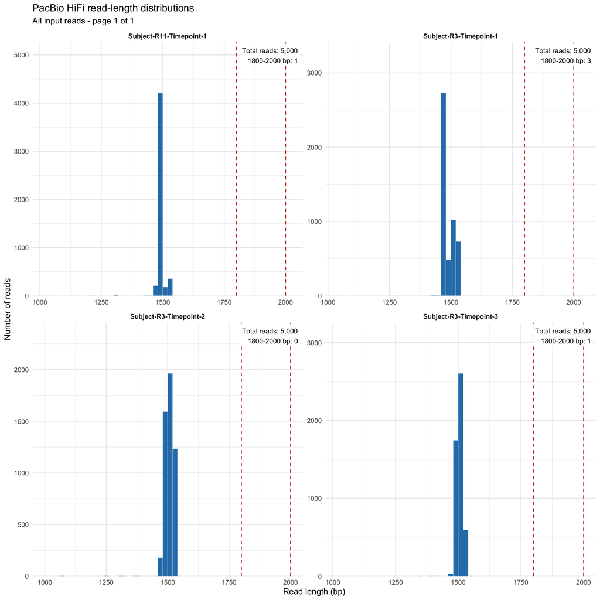

```r
write_distribution_pdf("length", length_plot_path)
show_distribution_pages("length")
```

### 6.3.2 Read-QV Distribution

The dashed line marks the QV filtering cutoff. Each QV facet shows total reads and reads passing the QV cutoff. Length-range counts appear only on the read-length plots.

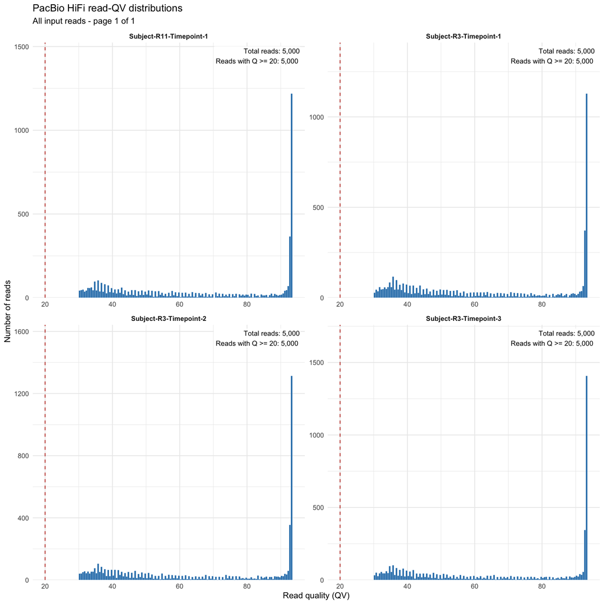

```r
write_distribution_pdf("quality", quality_plot_path)
show_distribution_pages("quality")
```

```r
# Aggregate caches are no longer needed after both PDFs and inline figures exist.
unlink(sample_qc$HistogramPath)
```

# 7 Export Results

## 7.1 Save QC Tables to Excel

Keep the complete per-read audit in `per_read_statistics.tsv.gz`. Create a typed run summary and a complete per-sample QC table, write both with the shared add_sheet_to_excel_function.R helper, and document every exported column with build_column_dictionary_function.R.

The report prints the completed workbook and compressed audit paths after all result sheets, column definitions, and header comments have been written.

```
## QC workbook written to: /Users/jon/Documents/workflows/DADA2_16S_PacBio_HiFi_Workflow/example/run_results/mapping_only/2_quality_filtered_reads/quality_and_read_length_summary.xlsx
```

```
## Complete per-read audit written to: /Users/jon/Documents/workflows/DADA2_16S_PacBio_HiFi_Workflow/example/run_results/mapping_only/2_quality_filtered_reads/per_read_statistics.tsv.gz
```

## 7.2 Final QC Decision

Confirm that every input produced a complete summary and every required output file exists. A `REVIEW` status is not a processing failure because the thresholds are descriptive review rules rather than filters.

```r
# Structural completion is required even when one or more biological samples
# are flagged for review.
qc_complete <-
  nrow(sample_qc) == nrow(sample_manifest) &&
  all(sample_qc$TotalReads > 0) &&
  all(file_exists(sample_qc$FilteredFASTQ)) &&
  file_exists(workbook_path) &&
  file_exists(read_statistics_path) &&
  file_exists(length_plot_path) &&
  file_exists(quality_plot_path)

if (!qc_complete) {
  stop("Step 2 QC outputs are incomplete. Review the preceding diagnostics.")
}
```

After structural validation succeeds, this final status summarizes the number of samples, reads passing Q ≥ 20, and samples flagged for length-distribution review.

```
## Step 2 complete — 4 samples summarized; 20000 reads retained at Q 20 ; 4 passed configured review rules and 0 require review.
```